# Assigment09

```python
import pandas as pd
import seaborn as sns
```

```python
penguins = sns.load_dataset("penguins")
PremStats = pd.read_csv("../data/EPL_20_21.csv")
```

```python
penguins.head()
```

|  | species | island | bill_length_mm | bill_depth_mm | flipper_length_mm | body_mass_g | sex |
| --- | --- | --- | --- | --- | --- | --- | --- |
| 0 | Adelie | Torgersen | 39.1 | 18.7 | 181.0 | 3750.0 | Male |
| 1 | Adelie | Torgersen | 39.5 | 17.4 | 186.0 | 3800.0 | Female |
| 2 | Adelie | Torgersen | 40.3 | 18.0 | 195.0 | 3250.0 | Female |
| 3 | Adelie | Torgersen | NaN | NaN | NaN | NaN | NaN |
| 4 | Adelie | Torgersen | 36.7 | 19.3 | 193.0 | 3450.0 | Female |

### Portfolio assignment 9

25 min: Perform a bivariate analysis on the columns with numerical data in the penguins dataset.

- Use corr() on the DataFrame to calculate all the correlations. Use the code example above to show the correlation table with colors.
- Look at the corrrelations. Do they match your expectations?
- Show a scatter plot for
  - The strongest positive correlation
  - The strongest negative correlation
  - The weakest correlation

Ik denk dat er een verband is tussen de flipper length en de bill length

```python
penguins[['flipper_length_mm', 'bill_length_mm']].corr()
```

|  | flipper_length_mm | bill_length_mm |
| --- | --- | --- |
| flipper_length_mm | 1.000000 | 0.656181 |
| bill_length_mm | 0.656181 | 1.000000 |

```python
penguins.corr()
```

|  | bill_length_mm | bill_depth_mm | flipper_length_mm | body_mass_g |
| --- | --- | --- | --- | --- |
| bill_length_mm | 1.000000 | -0.235053 | 0.656181 | 0.595110 |
| bill_depth_mm | -0.235053 | 1.000000 | -0.583851 | -0.471916 |
| flipper_length_mm | 0.656181 | -0.583851 | 1.000000 | 0.871202 |
| body_mass_g | 0.595110 | -0.471916 | 0.871202 | 1.000000 |

Er zit een grotere correlatie tussen de body mass en de flipper length. Dit heeft denk te maken met hoe groter de penguin hoe groter de flipper en ook hoe zwaarder dus.

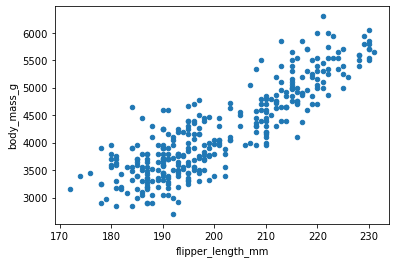

```python
penguins.plot(kind="scatter", x="flipper_length_mm", y="body_mass_g")
```

Dit is de scatterplot van de eigenschappen met de meeste correlatie

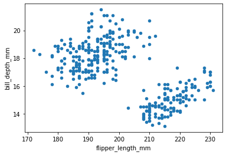

```python
penguins.plot(kind="scatter", x="flipper_length_mm", y="bill_depth_mm")
```

En dit de sterkste negative hier zie je duidelijk 2 groepen dus mischien heeft dit wel iets te maken met bijvoorbeeld de soort

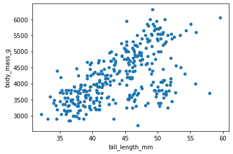

```python
penguins.plot(kind="scatter", x="bill_length_mm", y="body_mass_g")
```